# O.4 Frontiers OXT

#### 4.4.1.9 Vas_Bine_Pre_OGL Vas_Bine_Post_OGL Vas_Bine_Pre_ECRAN Vas_Bine_Post_ECRAN

#### 4.4.1.10 Descriptives

| item | group1 | group2 | vars | n | mean | sd | median | trimmed | mad | min | max | range | skew | kurtosis | se |
| --- | --- | --- | --- | --- | --- | --- | --- | --- | --- | --- | --- | --- | --- | --- | --- |
| 1 | Post | ECRAN | 1 | 26 | 70.00000 | 19.76057 | 74.0 | 71.50000 | 14.0847 | 8 | 99 | 91 | -1.0280694 | 1.4900680 | 3.875366 |
| 2 | Pre | ECRAN | 1 | 26 | 66.61538 | 20.93242 | 68.5 | 68.00000 | 23.7216 | 3 | 100 | 97 | -0.8442576 | 0.9947348 | 4.105185 |
| 3 | Post | OGL | 1 | 26 | 69.69231 | 18.86747 | 70.0 | 70.27273 | 23.7216 | 29 | 100 | 71 | -0.1802474 | -0.9981140 | 3.700216 |
| 4 | Pre | OGL | 1 | 26 | 67.07692 | 17.39178 | 71.0 | 67.86364 | 17.7912 | 32 | 91 | 59 | -0.4243997 | -0.9606836 | 3.410808 |

NA

| .y. | group1 | group2 | p | p.adj | p.format | p.signif | method |
| --- | --- | --- | --- | --- | --- | --- | --- |
| value | Vas_Bine_Pre_OGL | Vas_Bine_Post_OGL | 0.2617320 | 1.0 | 0.26 | ns | T-test |
| value | Vas_Bine_Pre_OGL | Vas_Bine_Pre_ECRAN | 0.9153942 | 1.0 | 0.92 | ns | T-test |
| value | Vas_Bine_Pre_OGL | Vas_Bine_Post_ECRAN | 0.4091268 | 1.0 | 0.41 | ns | T-test |
| value | Vas_Bine_Post_OGL | Vas_Bine_Pre_ECRAN | 0.5224766 | 1.0 | 0.52 | ns | T-test |
| value | Vas_Bine_Post_OGL | Vas_Bine_Post_ECRAN | 0.9365978 | 1.0 | 0.94 | ns | T-test |
| value | Vas_Bine_Pre_ECRAN | Vas_Bine_Post_ECRAN | 0.1161065 | 0.7 | 0.12 | ns | T-test |

#### 4.4.1.11 t Change

| estimate | statistic | p.value | parameter | conf.low | conf.high | method | alternative |
| --- | --- | --- | --- | --- | --- | --- | --- |
| -0.7692308 | -0.2711671 | 0.788489 | 25 | -6.611609 | 5.073147 | Paired t-test | two.sided |

#### 4.4.1.12 ANCOVA Post

##### 4.4.1.12.1 Homogeneity test

| F | df1 | df2 | p |
| --- | --- | --- | --- |
| 0.1047036 | 1 | 50 | 0.7476061 |

##### 4.4.1.12.2 ANCOVA output

| name | ss | df | ms | F | p | etaSq | etaSqP |
| --- | --- | --- | --- | --- | --- | --- | --- |
| Pre | 12971.272554 | 1 | 12971.272554 | 111.69818168 | 0.0000000000000310801 | 0.6948474635 | 0.695080557 |
| OglEcran | 6.260207 | 1 | 6.260207 | 0.05390788 | 0.8173646651731402146 | 0.0003353479 | 0.001098952 |
| Residuals | 5690.265908 | 49 | 116.127876 | NA | NA | NA | NA |

##### 4.4.1.12.3 Post Hoc

| OglEcran1 | sep | OglEcran2 | md | se | df | t | ptukey |
| --- | --- | --- | --- | --- | --- | --- | --- |
| ECRAN | - | OGL | 0.6939931 | 2.989021 | 49 | 0.2321807 | 0.8173647 |

##### 4.4.1.12.4 Homogeneity of regression slopes

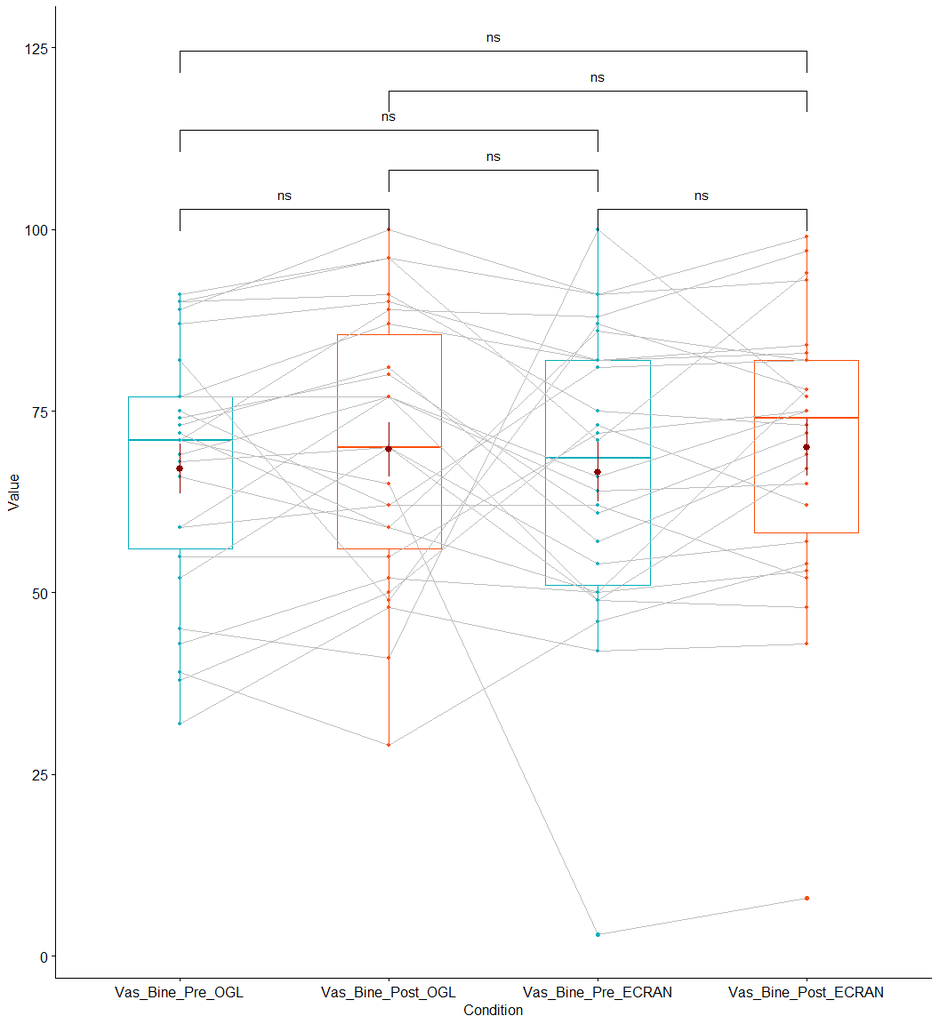

```r
func_ancova_multibox(Data_fem, "ID", "IOS_Pre_OGL", "IOS_Post_OGL", "IOS_Pre_ECRAN", "IOS_Post_ECRAN")                            # sig
```

#### 4.4.1.13 IOS_Pre_OGL IOS_Post_OGL IOS_Pre_ECRAN IOS_Post_ECRAN

#### 4.4.1.14 Descriptives

| item | group1 | group2 | vars | n | mean | sd | median | trimmed | mad | min | max | range | skew | kurtosis | se |
| --- | --- | --- | --- | --- | --- | --- | --- | --- | --- | --- | --- | --- | --- | --- | --- |
| 1 | Post | ECRAN | 1 | 19 | 2.210526 | 1.357242 | 2 | 2.058824 | 1.4826 | 1 | 6 | 5 | 1.1553029 | 0.76788739 | 0.3113726 |
| 2 | Pre | ECRAN | 1 | 19 | 2.315789 | 1.376494 | 2 | 2.235294 | 1.4826 | 1 | 5 | 4 | 0.6677876 | -0.92400226 | 0.3157895 |
| 3 | Post | OGL | 1 | 19 | 3.052632 | 1.580214 | 3 | 2.941176 | 1.4826 | 1 | 7 | 6 | 0.8789942 | 0.09252713 | 0.3625259 |
| 4 | Pre | OGL | 1 | 19 | 2.157895 | 1.167293 | 2 | 2.000000 | 1.4826 | 1 | 6 | 5 | 1.6978033 | 3.48933927 | 0.2677954 |

NA

| .y. | group1 | group2 | p | p.adj | p.format | p.signif | method |
| --- | --- | --- | --- | --- | --- | --- | --- |
| value | IOS_Pre_OGL | IOS_Post_OGL | 0.0003053213 | 0.0018 | 0.00031 | *** | T-test |
| value | IOS_Pre_OGL | IOS_Pre_ECRAN | 0.5461049744 | 1.0000 | 0.54610 | ns | T-test |
| value | IOS_Pre_OGL | IOS_Post_ECRAN | 0.8040828402 | 1.0000 | 0.80408 | ns | T-test |
| value | IOS_Post_OGL | IOS_Pre_ECRAN | 0.0742097577 | 0.3000 | 0.07421 | ns | T-test |
| value | IOS_Post_OGL | IOS_Post_ECRAN | 0.0281050818 | 0.1400 | 0.02811 | * | T-test |
| value | IOS_Pre_ECRAN | IOS_Post_ECRAN | 0.3305649313 | 0.9900 | 0.33056 | ns | T-test |

#### 4.4.1.15 t Change

| estimate | statistic | p.value | parameter | conf.low | conf.high | method | alternative |
| --- | --- | --- | --- | --- | --- | --- | --- |
| 1 | 4.623311 | 0.0002111495 | 18 | 0.5455806 | 1.454419 | Paired t-test | two.sided |

#### 4.4.1.16 ANCOVA Post

##### 4.4.1.16.1 Homogeneity test

| F | df1 | df2 | p |
| --- | --- | --- | --- |
| 0.4586258 | 1 | 36 | 0.5025959 |

##### 4.4.1.16.2 ANCOVA output

| name | ss | df | ms | F | p | etaSq | etaSqP |
| --- | --- | --- | --- | --- | --- | --- | --- |
| Pre | 60.54162 | 1 | 60.5416234 | 120.64452 | 0.0000000000006880527 | 0.6909931 | 0.7751286 |
| OglEcran | 9.51012 | 1 | 9.5101197 | 18.95132 | 0.0001110626229327492 | 0.1085439 | 0.3512671 |
| Residuals | 17.56364 | 35 | 0.5018183 | NA | NA | NA | NA |

##### 4.4.1.16.3 Post Hoc

| OglEcran1 | sep | OglEcran2 | md | se | df | t | ptukey |
| --- | --- | --- | --- | --- | --- | --- | --- |
| ECRAN | - | OGL | -1.002551 | 0.2302962 | 35 | -4.353312 | 0.0001110626 |

##### 4.4.1.16.4 Homogeneity of regression slopes

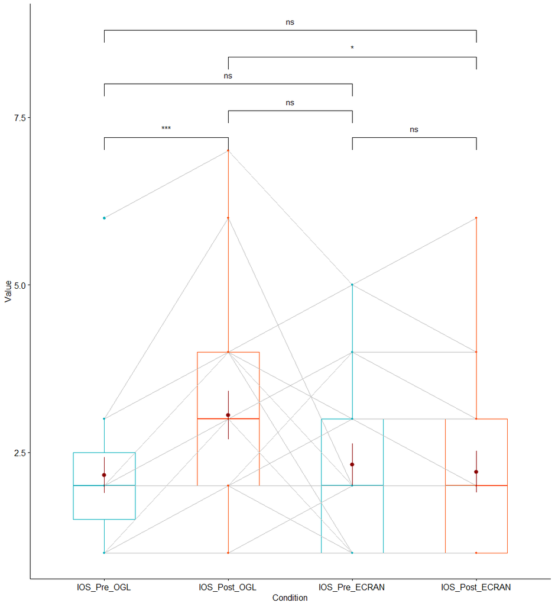

```r
# Males
cat("### Masc")
```

### 4.4.2 Masc

```r
Data_masc %>%
  func_ancova_multibox("ID", "OXT_Pre_OGL", "OXT_Post_OGL", "OXT_Pre_ECRAN", "OXT_Post_ECRAN")                                     # ns
```

#### 4.4.2.1 OXT_Pre_OGL OXT_Post_OGL OXT_Pre_ECRAN OXT_Post_ECRAN

#### 4.4.2.2 Descriptives

| item | group1 | group2 | vars | n | mean | sd | median | trimmed | mad | min | max | range | skew | kurtosis | se |
| --- | --- | --- | --- | --- | --- | --- | --- | --- | --- | --- | --- | --- | --- | --- | --- |
| 1 | Post | ECRAN | 1 | 22 | 1.0839934 | 0.2632482 | 1.0658850 | 1.0982969 | 0.3758966 | 0.6048387 | 1.440981 | 0.8361424 | -0.3113054 | -1.2386316 | 0.05612470 |
| 2 | Pre | ECRAN | 1 | 22 | 0.9940307 | 0.2767541 | 0.9862034 | 0.9788994 | 0.2836614 | 0.5900621 | 1.609105 | 1.0190431 | 0.3951247 | -0.7710942 | 0.05900418 |
| 3 | Post | OGL | 1 | 22 | 1.0486696 | 0.3071348 | 1.0399256 | 1.0368486 | 0.2939940 | 0.5322802 | 1.771313 | 1.2390331 | 0.3112290 | -0.3872721 | 0.06548135 |
| 4 | Pre | OGL | 1 | 22 | 1.1140774 | 0.3085154 | 1.0844544 | 1.1042460 | 0.2709021 | 0.5804878 | 1.743862 | 1.1633738 | 0.2720035 | -0.8310896 | 0.06577569 |

NA

| .y. | group1 | group2 | p | p.adj | p.format | p.signif | method |
| --- | --- | --- | --- | --- | --- | --- | --- |
| value | OXT_Pre_OGL | OXT_Post_OGL | 0.3026794 | 1.00 | 0.30 | ns | T-test |
| value | OXT_Pre_OGL | OXT_Pre_ECRAN | 0.1431379 | 0.86 | 0.14 | ns | T-test |
| value | OXT_Pre_OGL | OXT_Post_ECRAN | 0.6320423 | 1.00 | 0.63 | ns | T-test |
| value | OXT_Post_OGL | OXT_Pre_ECRAN | 0.4043210 | 1.00 | 0.40 | ns | T-test |
| value | OXT_Post_OGL | OXT_Post_ECRAN | 0.6461905 | 1.00 | 0.65 | ns | T-test |
| value | OXT_Pre_ECRAN | OXT_Post_ECRAN | 0.1570690 | 0.86 | 0.16 | ns | T-test |

#### 4.4.2.3 t Change

| estimate | statistic | p.value | parameter | conf.low | conf.high | method | alternative |
| --- | --- | --- | --- | --- | --- | --- | --- |
| -0.1553705 | -1.441572 | 0.1641704 | 21 | -0.3795082 | 0.0687672 | Paired t-test | two.sided |

#### 4.4.2.4 ANCOVA Post

##### 4.4.2.4.1 Homogeneity test

| F | df1 | df2 | p |
| --- | --- | --- | --- |
| 0.1928863 | 1 | 42 | 0.6627765 |

##### 4.4.2.4.2 ANCOVA output

| name | ss | df | ms | F | p | etaSq | etaSqP |
| --- | --- | --- | --- | --- | --- | --- | --- |
| Pre | 0.86697414 | 1 | 0.86697414 | 13.834955 | 0.0005986971 | 0.24562172 | 0.2523017 |
| OglEcran | 0.09345388 | 1 | 0.09345388 | 1.491314 | 0.2289888249 | 0.02647634 | 0.0350969 |
| Residuals | 2.56928480 | 41 | 0.06266548 | NA | NA | NA | NA |

##### 4.4.2.4.3 Post Hoc

| OglEcran1 | sep | OglEcran2 | md | se | df | t | ptukey |
| --- | --- | --- | --- | --- | --- | --- | --- |
| ECRAN | - | OGL | 0.09417622 | 0.07711818 | 41 | 1.221193 | 0.2289888 |

##### 4.4.2.4.4 Homogeneity of regression slopes

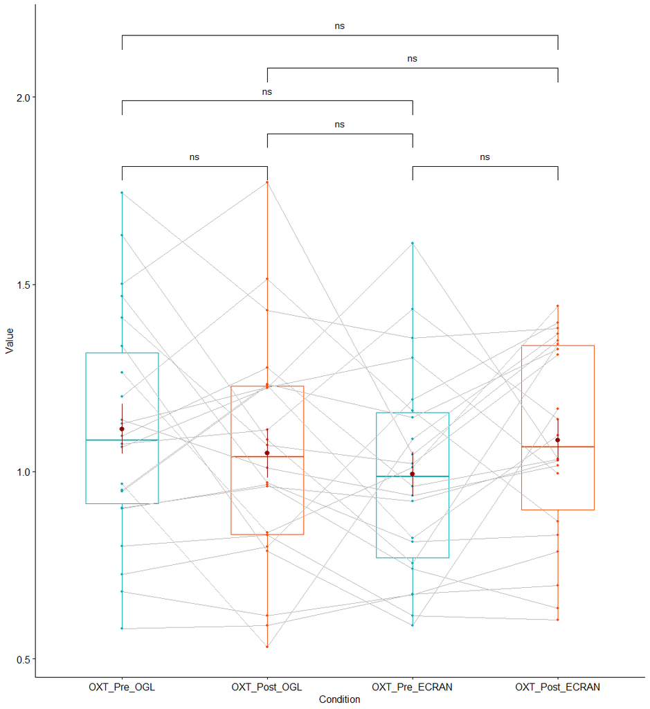

```r
func_ancova_multibox(Data_masc, "ID", "Vas_Stres_Pre_OGL", "Vas_Stres_Post_OGL", "Vas_Stres_Pre_ECRAN", "Vas_Stres_Post_ECRAN")    # ns
```

#### 4.4.2.5 Vas_Stres_Pre_OGL Vas_Stres_Post_OGL Vas_Stres_Pre_ECRAN Vas_Stres_Post_ECRAN

#### 4.4.2.6 Descriptives

| item | group1 | group2 | vars | n | mean | sd | median | trimmed | mad | min | max | range | skew | kurtosis | se |
| --- | --- | --- | --- | --- | --- | --- | --- | --- | --- | --- | --- | --- | --- | --- | --- |
| 1 | Post | ECRAN | 1 | 23 | 18.13043 | 19.18168 | 11 | 15.52632 | 16.3086 | 0 | 72 | 72 | 1.093193 | 0.5197563 | 3.999656 |
| 2 | Pre | ECRAN | 1 | 23 | 18.17391 | 19.94914 | 13 | 15.00000 | 16.3086 | 0 | 70 | 70 | 1.188149 | 0.4594021 | 4.159684 |
| 3 | Post | OGL | 1 | 23 | 17.43478 | 18.84102 | 12 | 14.57895 | 14.8260 | 0 | 65 | 65 | 1.145066 | 0.2524254 | 3.928625 |
| 4 | Pre | OGL | 1 | 23 | 18.78261 | 20.52262 | 16 | 15.31579 | 16.3086 | 0 | 72 | 72 | 1.341078 | 0.9471938 | 4.279262 |

NA

| .y. | group1 | group2 | p | p.adj | p.format | p.signif | method |
| --- | --- | --- | --- | --- | --- | --- | --- |
| value | Vas_Stres_Pre_OGL | Vas_Stres_Post_OGL | 0.3856450 | 1 | 0.39 | ns | T-test |
| value | Vas_Stres_Pre_OGL | Vas_Stres_Pre_ECRAN | 0.8622761 | 1 | 0.86 | ns | T-test |
| value | Vas_Stres_Pre_OGL | Vas_Stres_Post_ECRAN | 0.8376033 | 1 | 0.84 | ns | T-test |
| value | Vas_Stres_Post_OGL | Vas_Stres_Pre_ECRAN | 0.7897433 | 1 | 0.79 | ns | T-test |
| value | Vas_Stres_Post_OGL | Vas_Stres_Post_ECRAN | 0.8146277 | 1 | 0.81 | ns | T-test |
| value | Vas_Stres_Pre_ECRAN | Vas_Stres_Post_ECRAN | 0.9818213 | 1 | 0.98 | ns | T-test |

#### 4.4.2.7 t Change

| estimate | statistic | p.value | parameter | conf.low | conf.high | method | alternative |
| --- | --- | --- | --- | --- | --- | --- | --- |
| -1.304348 | -0.432093 | 0.6698794 | 22 | -7.564694 | 4.955998 | Paired t-test | two.sided |

#### 4.4.2.8 ANCOVA Post

##### 4.4.2.8.1 Homogeneity test

| F | df1 | df2 | p |
| --- | --- | --- | --- |
| 0.01699639 | 1 | 44 | 0.8968678 |

##### 4.4.2.8.2 ANCOVA output

| name | ss | df | ms | F | p | etaSq | etaSqP |
| --- | --- | --- | --- | --- | --- | --- | --- |
| Pre | 13289.65769 | 1 | 13289.65769 | 218.5629100 | 0.000000000000000001825937 | 0.834707882 | 0.835603603 |
| OglEcran | 17.06678 | 1 | 17.06678 | 0.2806818 | 0.598979715879040752746221 | 0.001071945 | 0.006485152 |
| Residuals | 2614.60318 | 43 | 60.80473 | NA | NA | NA | NA |

##### 4.4.2.8.3 Post Hoc

| OglEcran1 | sep | OglEcran2 | md | se | df | t | ptukey |
| --- | --- | --- | --- | --- | --- | --- | --- |
| ECRAN | - | OGL | 1.218367 | 2.299699 | 43 | 0.5297941 | 0.5989797 |

##### 4.4.2.8.4 Homogeneity of regression slopes

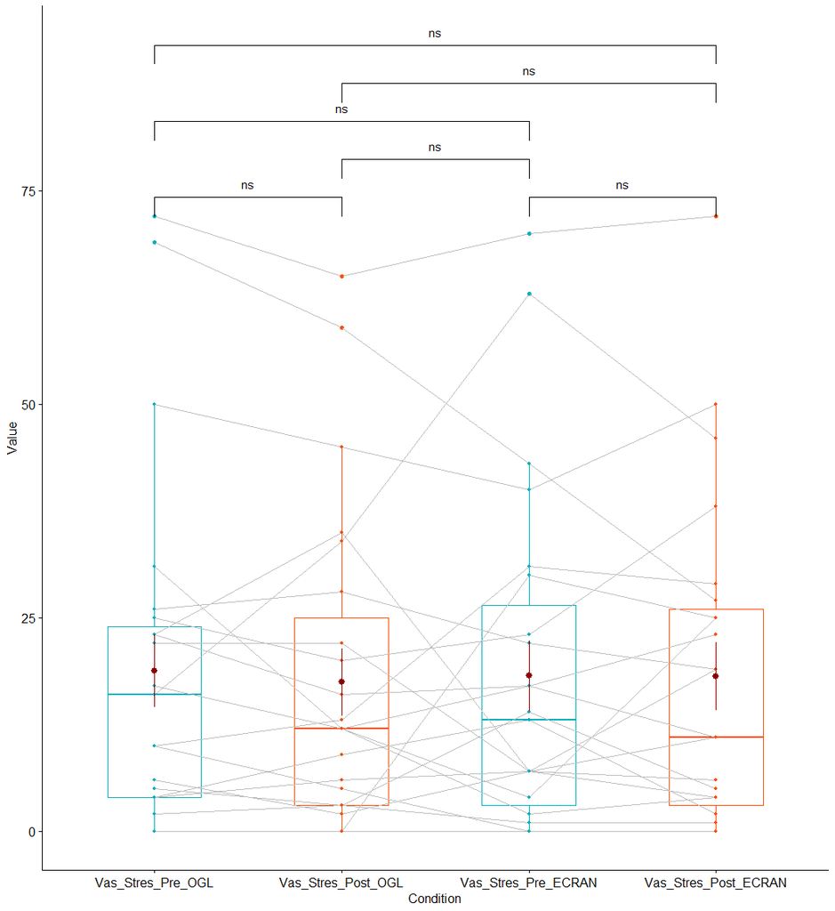

```r
func_ancova_multibox(Data_masc, "ID", "Vas_Bine_Pre_OGL", "Vas_Bine_Post_OGL", "Vas_Bine_Pre_ECRAN", "Vas_Bine_Post_ECRAN")        # ns
```